# GANS model for image generation using MNIST Dataset

- This GANS model is trained on the MNIST dataset. The Generator is trained on noise data and the loss computed helps learn the appropriate latent space.
- Increasing the number of epochs and utilzing more than one loss value helps avoid mode collapse.
- The GANS model successfully learns the latent space to generate more hand-written digit samples with different variations

The Generator creates more images and the discriminator learns to classify whether the image is real or fake. Based on the discriminators results, the generator is then used to create more samples and the this process is repeated with each epoch. The goal for the discriminator is set to ensure that the generator produced images are easy to identify whereas the generator is incentivised to learn to produce images that the discriminator is unable to identify as fake.

MNIST Dataset The MNIST dataset is a famous dataset in the field of machine learning. It consists of 28x28 pixel grayscale images of handwritten digits (0-9). The dataset contains 60,000 training images and 10,000 test images, making it a suitable choice for various machine learning tasks, including digit classification and image generation.

Its significance lies in its simplicity, making it a benchmark dataset for testing new machine learning algorithms and models. Researchers and developers often use MNIST as a starting point for experimenting with deep learning techniques because of its small size and easy-to-understand structure.

### Introduction to GANs

Generative Adversarial Networks (GANs) are a class of deep learning models designed for generative tasks. They consist of two key components: the Generator and the Discriminator. The Generator attempts to create data (e.g., images) from random noise, while the Discriminator aims to distinguish between real data and fake data produced by the Generator.

In a GAN, these two networks are trained simultaneously through a competitive process. The Generator gets better at creating data that mimics the real data distribution over time, and the Discriminator gets better at distinguishing real from fake data. This adversarial process helps the Generator improve its ability to generate realistic data, making GANs especially useful for image generation tasks.

Generative Adversarial Networks (GANs) are a class of deep learning models designed for generative tasks. They consist of two key components: the Generator and the Discriminator. The Generator attempts to create data (e.g., images) from random noise, while the Discriminator aims to distinguish between real data and fake data produced by the Generator.

In a GAN, these two networks are trained simultaneously through a competitive process. The Generator gets better at creating data that mimics the real data distribution over time, and the Discriminator gets better at distinguishing real from fake data. This adversarial process helps the Generator improve its ability to generate realistic data, making GANs especially useful for image generation tasks.

## Challenges faced and future updates

- The model is a generalized one and can be used to generate more hand-written digit samples, or further customized to use conditions to produce completely different results
- Limited Data and the computational complexity of training 2 models at each epoch makes the training process cumbersome and time consuming. This model used the MNIST dataset which has input data that can be managed on limited resources but the model can easily be scaled up to handle more datasets and use cases

```python
import torch
import torch.nn as nn
import torch.optim as optim
import torchvision
from torchvision import datasets, transforms
from torch.utils.data import DataLoader
import matplotlib.pyplot as plt
```

```python
import torch
import torch.nn as nn
import torch.optim as optim
from torchvision import datasets, transforms
from torch.utils.data import DataLoader
import matplotlib.pyplot as plt
```

### Load Dataset

setting up a batch size, transforming the images to tensors, and normalizing them. This normalization scales the pixel values to the range [-1, 1], which helps training stability by making it easier for the generator and discriminator to work with.

```python
batch_size = 64
transform = transforms.Compose([
    transforms.ToTensor(),
    transforms.Normalize((0.5,), (0.5,))
])
mnist_dataset = datasets.MNIST(
    root='./data', train=True, transform=transform, download=True)
dataloader = DataLoader(mnist_dataset, batch_size=batch_size, shuffle=True)
```

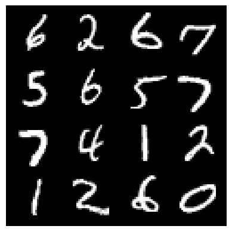

```python
# Here are sample images from the dataset
sample_images, _ = next(iter(dataloader))
sample_images_grid = torchvision.utils.make_grid(
    sample_images[:16], nrow=4, padding=2, normalize=True)
plt.imshow(sample_images_grid.permute(1, 2, 0))
plt.axis('off')
plt.show()
```

### Define GANS model

```python
# Define the generator and discriminator networks
class Generator(nn.Module):
    def __init__(self, latent_dim, output_dim):
        super(Generator, self).__init__()
        self.main = nn.Sequential(
            nn.Linear(latent_dim, 256),
            nn.ReLU(),
            nn.Linear(256, output_dim),
            nn.Tanh()
        )

    def forward(self, x):
        return self.main(x)


class Discriminator(nn.Module):
    def __init__(self, input_dim):
        super(Discriminator, self).__init__()
        self.main = nn.Sequential(
            nn.Linear(input_dim, 256),
            nn.LeakyReLU(0.2),
            nn.Linear(256, 1),
            nn.Sigmoid()
        )

    def forward(self, x):
        return self.main(x)
```

### Train the model

[figure not shown]

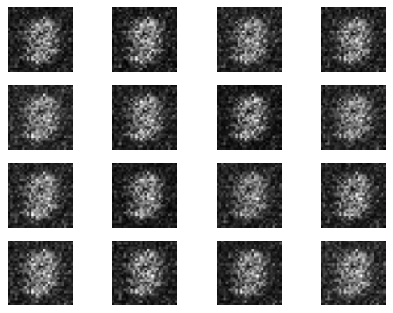

```python
# Hyperparameters
latent_dim = 100
image_size = 28 * 28
batch_size = 64
epochs = 200
visualize_interval = 10


# Define GAN components
generator = Generator(latent_dim, image_size)
discriminator = Discriminator(image_size)

# Loss function and optimizers
criterion = nn.BCELoss()
optimizer_G = optim.Adam(generator.parameters(), lr=0.0002)
optimizer_D = optim.Adam(discriminator.parameters(), lr=0.0002)

# Load the MNIST dataset
transform = transforms.Compose([
    transforms.ToTensor(),
    transforms.Normalize((0.5,), (0.5,))
])

mnist_dataset = datasets.MNIST(root='./data', train=True, transform=transform, download=True)
dataloader = DataLoader(mnist_dataset, batch_size=batch_size, shuffle=True)

# Training loop
for epoch in range(epochs):
    for i, (real_images, _) in enumerate(dataloader):
        batch_size = real_images.size(0)
        real_images = real_images.view(-1, image_size)

        # Train Discriminator
        optimizer_D.zero_grad()
        real_labels = torch.ones(batch_size, 1)
        fake_labels = torch.zeros(batch_size, 1)

        # Discriminator on real data
        real_outputs = discriminator(real_images)
        d_loss_real = criterion(real_outputs, real_labels)
        d_loss_real.backward()

        # Discriminator on fake data
        noise = torch.randn(batch_size, latent_dim)
        fake_images = generator(noise)
        fake_outputs = discriminator(fake_images.detach())
        d_loss_fake = criterion(fake_outputs, fake_labels)
        d_loss_fake.backward()

        optimizer_D.step()

        # Train Generator
        optimizer_G.zero_grad()
        fake_outputs = discriminator(fake_images)
        g_loss = criterion(fake_outputs, real_labels)
        g_loss.backward()
        optimizer_G.step()

        if i % 400 == 0:
            print(
                f"[Epoch {epoch}/{epochs}] [Batch {i}/{len(dataloader)}] [D loss: {d_loss_real + d_loss_fake:.4f}] [G loss: {g_loss:.4f}]"
            )

     if epoch % visualize_interval == 0:
        # Generate and display images
        generator.eval()
        with torch.no_grad():
            noise = torch.randn(16, latent_dim)
            generated_images = generator(noise).view(-1, 1, 28, 28)

        fig, axs = plt.subplots(4, 4)
        for i in range(4):
            for j in range(4):
                axs[i, j].imshow(generated_images[i * 4 + j][0], cmap='gray')
                axs[i, j].axis('off')
        plt.show()
```

### Evaluate trained model

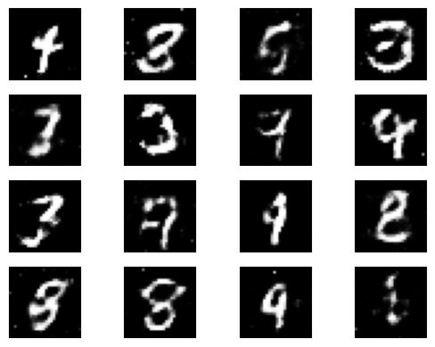

```python
# Generate some samples
generator.eval()
with torch.no_grad():
    noise = torch.randn(16, latent_dim)
    generated_images = generator(noise).view(-1, 1, 28, 28)

# Display generated images
fig, axs = plt.subplots(4, 4)
for i in range(4):
    for j in range(4):
        axs[i, j].imshow(generated_images[i * 4 + j][0], cmap="gray")
        axs[i, j].axis("off")
plt.show()
```

### Conclusion

In this project, I successfully implemented a Generative Adversarial Network (GAN) to generate realistic images of handwritten digits using the MNIST dataset. The GAN architecture consisted of a Generator and a Discriminator, which were trained adversarially to improve the quality of generated images.

The results of this project demonstrate the capability of the GAN to learn and generate diverse samples of handwritten digits. The generated images show a progression from random noise to recognizable digit patterns, indicating that the Generator has learned meaningful representations from the data.

This project not only serves as a valuable learning experience but also showcases my proficiency in deep learning and GANs. It highlights my ability to design, train, and evaluate complex neural networks for generative tasks.

### Future Work

Looking ahead, there are several avenues for future work and improvements:

1. **Architectural Enhancements**: Exploring more advanced GAN architectures, such as DCGAN (Deep Convolutional GAN) or StyleGAN, can lead to even better image generation results. These architectures have shown remarkable performance in generating high-quality images.
2. **Hyperparameter Tuning**: Continuously fine-tuning hyperparameters and conducting extensive experiments can help improve the stability and convergence of GAN training. Techniques like learning rate schedules and progressive growing can be explored.
3. **Larger Datasets**: Expanding beyond MNIST to more diverse and complex datasets, such as CIFAR-10 or ImageNet, would be a natural progression. Handling larger datasets would require optimizing memory and computation resources.
4. **Conditional GANs**: Implementing conditional GANs, where specific digit classes or attributes can be controlled during image generation, could be a fascinating extension of this project. This would allow for more targeted image synthesis.
5. **Deployment**: Taking the trained GAN model and deploying it as part of an interactive web application or mobile app could showcase the practical applications of generative models and enhance the project's visibility.

In conclusion, this portfolio project serves as a strong testament to my expertise in deep learning, GANs, and machine learning in general. It demonstrates my ability to tackle complex challenges, improve model performance, and envision future improvements. I look forward to further refining this project and exploring new horizons in the exciting field of generative AI.